# EDA

## Oglądam rozkłady zmiennych ilościowych:

- zmienna ‘Age’

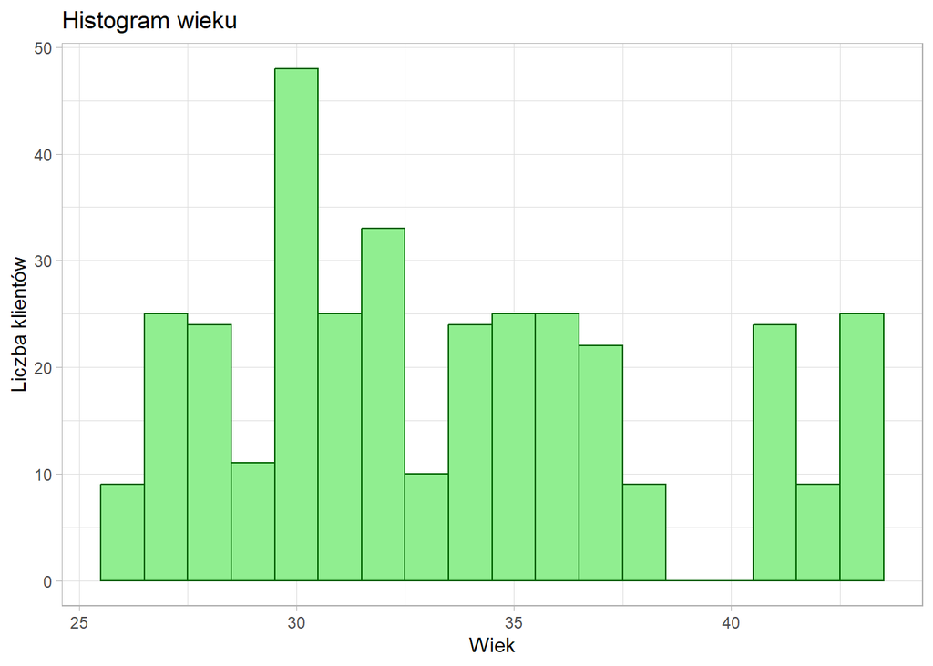

```r
ecommerce %>%
  ggplot() +
  geom_histogram(aes(x = Age),
                 binwidth = 1,
               color = "darkgreen",
               fill = "lightgreen") +
  theme_light() +
  labs(title= "Histogram wieku", x = "Wiek", y = "Liczba klientów")
```

```r
summary(ecommerce$Age)
```

```
##    Min. 1st Qu.  Median    Mean 3rd Qu.    Max.
##   26.00   30.00   32.00   33.58   37.00   43.00
```

Widzimy, że rozkład wieku jest dosyć nierównomierny. Przedział wiekowy jest od 26 do 43 lat. Brakuje nam osób w wieku 39, 40 lat. Zaś najwięcej osób jest w wieku 30 lat.

- zmienna `Total.Spend`:

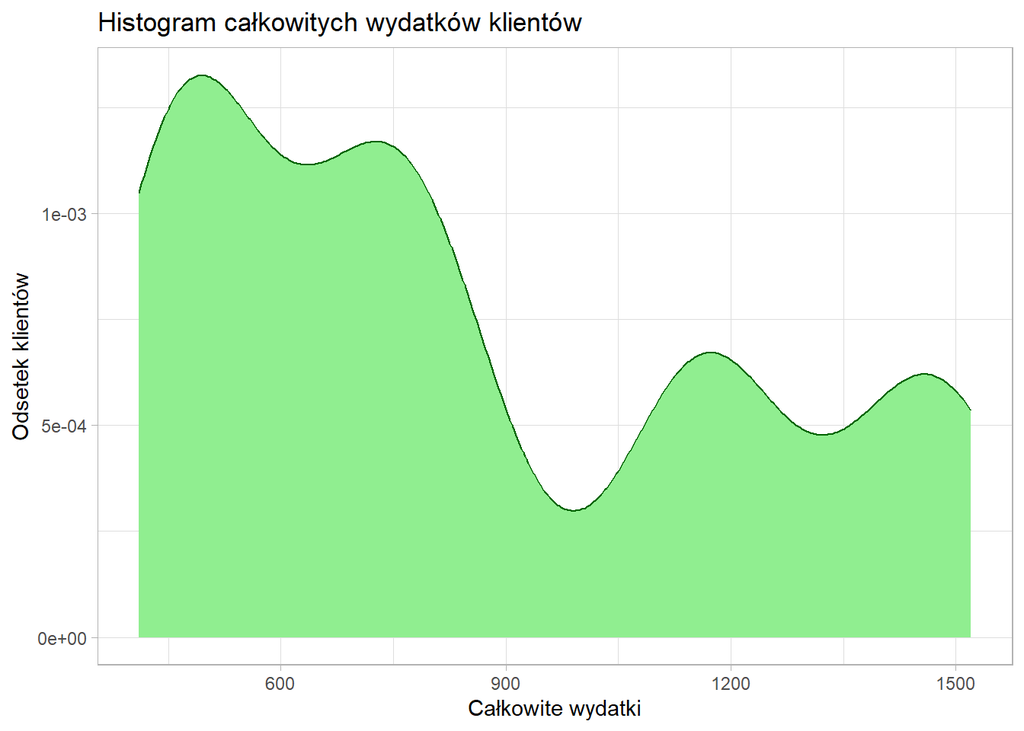

```r
ecommerce %>%
  ggplot() +
  geom_density(aes(x = Total.Spend),
               color = "darkgreen",
               fill = "lightgreen") +
  theme_light() +
  labs(title= "Histogram całkowitych wydatków klientów", x = "Całkowite wydatki", y = "Odsetek klientów")
```

Widzimy, że najczęściej klienci wydają między 400, a 800 zł.

- zmienna `Items.Purchased`:

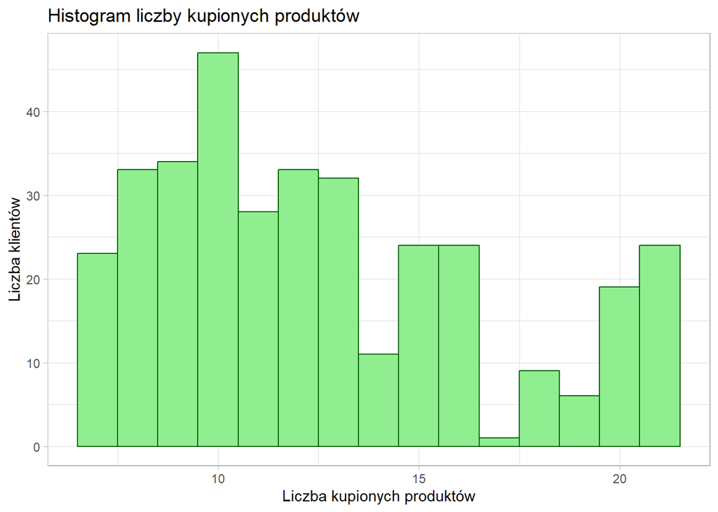

```r
ecommerce %>%
  ggplot() +
  geom_histogram(aes(x = Items.Purchased),
                 binwidth = 1,
               color = "darkgreen",
               fill = "lightgreen") +
  theme_light() +
  labs(title= "Histogram liczby kupionych produktów", x = "Liczba kupionych produktów", y = "Liczba klientów")
```

```r
summary(ecommerce$Items.Purchased)
```

```
##    Min. 1st Qu.  Median    Mean 3rd Qu.    Max.
##    7.00    9.00   12.00   12.63   15.00   21.00
```

Widzimy, że klienci najczęściej kupują 10 produktów. Jednak liczba osób kupujących od 7 do 13 produktów jest na podobnym poziomie. Najrzadziej klienci kupują 17-19 produktów.

*zmienna `Average.Rating`

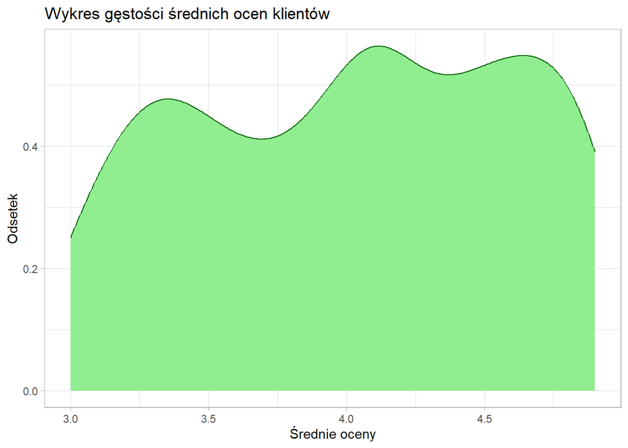

```r
ecommerce %>%
  ggplot() +
  geom_density(aes(x = Average.Rating),
               color = "darkgreen",
               fill = "lightgreen") +
  theme_light() +
  labs(title= "Wykres gęstości średnich ocen klientów", x = "Średnie oceny", y = "Odsetek")
```

Widzimy, że przeważają średnie oceny powyżej 4.0. Jednak niższych ocen jest również dużo.

```r
summary(ecommerce$Average.Rating)
```

```
##    Min. 1st Qu.  Median    Mean 3rd Qu.    Max.
##   3.000   3.500   4.100   4.024   4.500   4.900
```

Możemy zobaczyć, że 25% klientów średnio oceniło otrzymane produkty powyżej 4.5. Świadczy to dobrze o firmie.

- zmienna `Days.Since.Last.Purchase`

```r
summary(ecommerce$Days.Since.Last.Purchase)
```

```
##    Min. 1st Qu.  Median    Mean 3rd Qu.    Max.
##    9.00   15.00   23.00   26.61   38.00   63.00
```

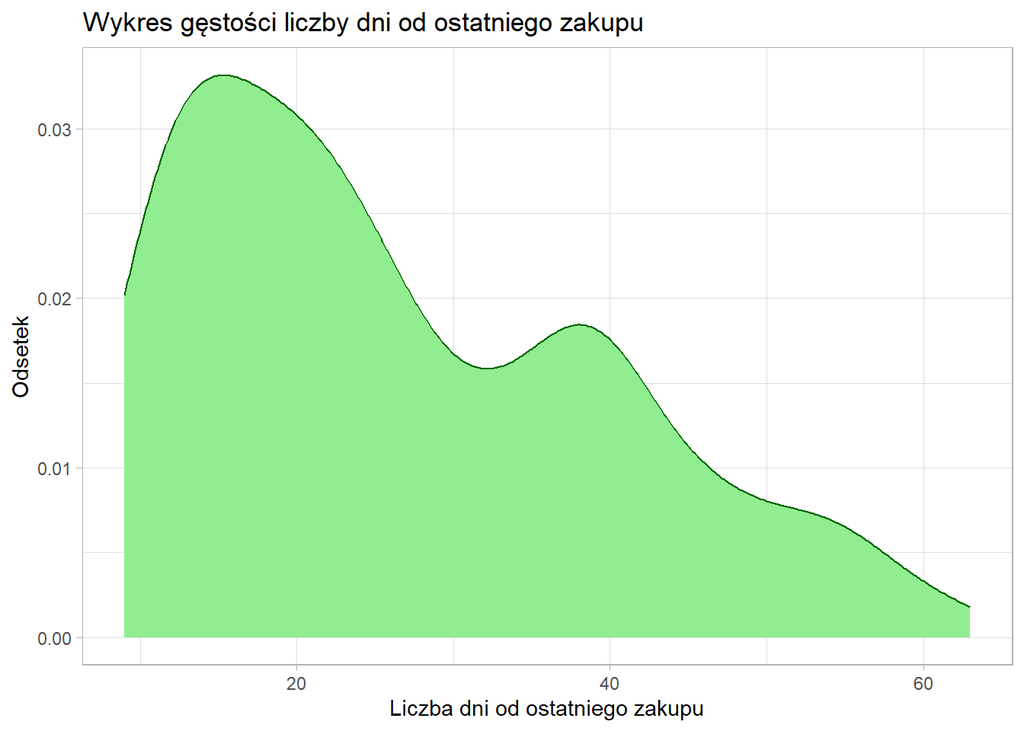

```r
ecommerce %>%
  ggplot() +
  geom_density(aes(x = Days.Since.Last.Purchase),
               color = "darkgreen",
               fill = "lightgreen") +
  theme_light() +
  labs(title= "Wykres gęstości liczby dni od ostatniego zakupu", x = "Liczba dni od ostatniego zakupu", y = "Odsetek")
```

Możemy zobaczyć, że rozkład jest prawostronnie skośny. 50% klientów dokonuje ponownie zakupu do 23 dni, czyli większość klientów dość często decyduje się na ponowny zakup.

## Oglądam rozkłady zmiennych jakościowych

- zmienna `Gender`

```r
table(ecommerce$Gender)
```

```
##
## Female   Male
##    173    175
```

Mamy prawie tyle samo klientów o płci męskiej i żeńskiej.

- zmienna `City`

```r
table(ecommerce$City)
```

```
##
##       Chicago       Houston   Los Angeles         Miami      New York
##            58            56            59            58            59
## San Francisco
##            58
```

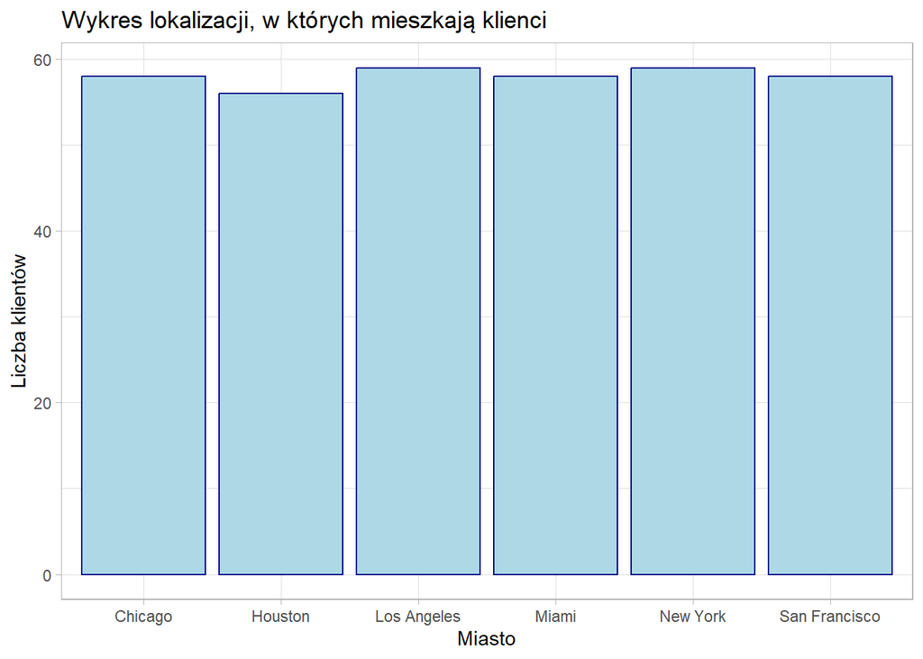

```r
ecommerce %>%
  ggplot() +
  geom_bar(aes(x = City),
               color = "darkblue",
               fill = "lightblue") +
  theme_light() +
  labs(title= "Wykres lokalizacji, w których mieszkają klienci", x = "Miasto", y = "Liczba klientów")
```

Rozkład jest dość równomierny. Nie ma znacznych różnić w ilości klientów z danego miasta.

- zmienna `Membership.Type:`

```r
table(ecommerce$Membership.Type)
```

```
##
## Bronze Silver   Gold
##    114    117    117
```

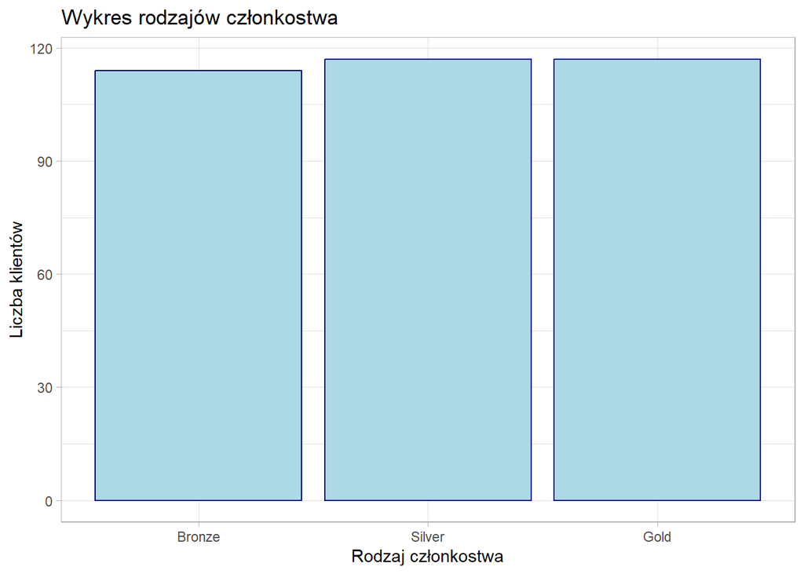

```r
ecommerce %>%
  ggplot() +
  geom_bar(aes(x = Membership.Type),
               color = "darkblue",
               fill = "lightblue") +
  theme_light() +
  labs(title= "Wykres rodzajów członkostwa", x = "Rodzaj członkostwa", y = "Liczba klientów")
```

W każdym rodzaju członkostwa mamy podobną liczbę klientów.

- zmienna `Discount Applied`

```r
table(ecommerce$Discount.Applied)
```

```
##
##   0   1
## 173 175
```

Mamy także praktycznie taką samą ilość otrzymanych zniżek.

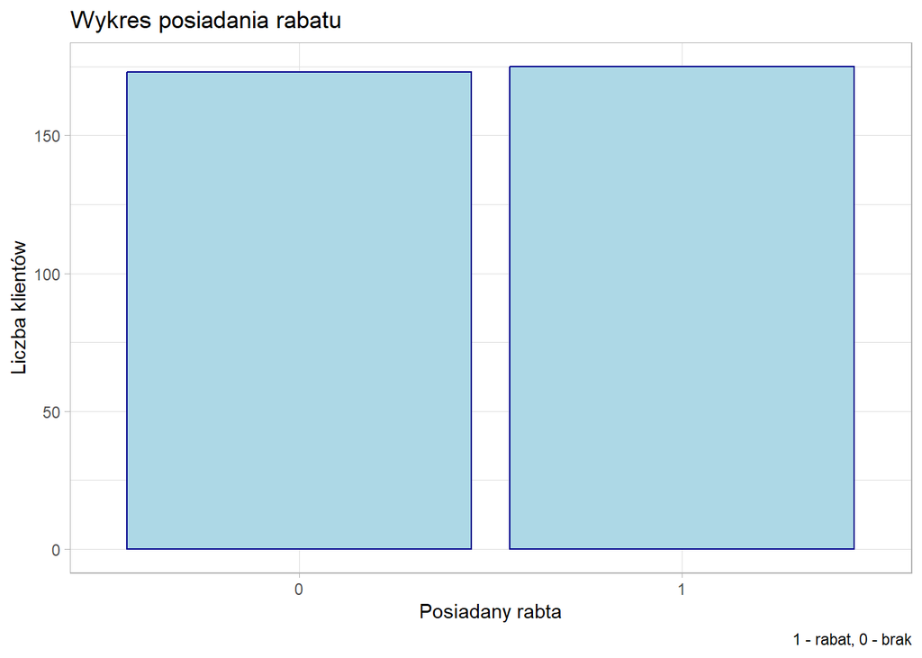

```r
ecommerce %>%
  ggplot() +
  geom_bar(aes(x = Discount.Applied),
               color = "darkblue",
               fill = "lightblue") +
  theme_light() +
  labs(title= "Wykres posiadania rabatu", x = "Posiadany rabta", y = "Liczba klientów", caption = "1 - rabat, 0 - brak")
```

- zmienna `Satisfaction.Level`

```r
table(ecommerce$Satisfaction.Level)
```

```
##
## Unsatisfied     Neutral   Satisfied
##         116         107         125
```

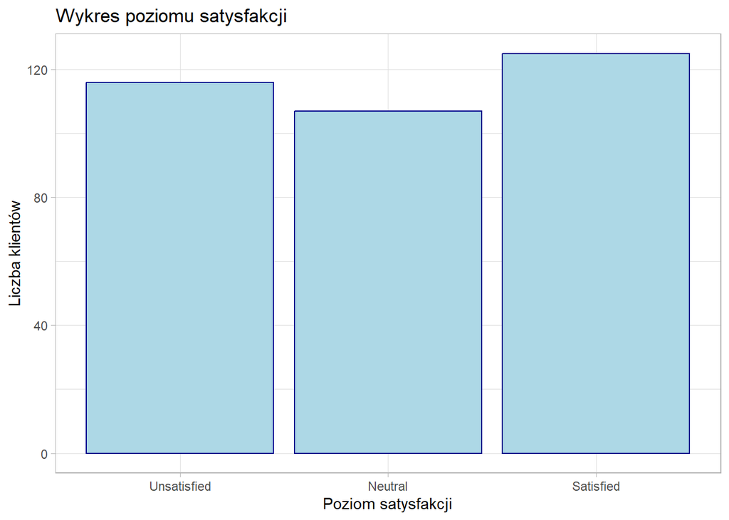

```r
ecommerce %>%
  ggplot() +
  geom_bar(aes(x = Satisfaction.Level),
               color = "darkblue",
               fill = "lightblue") +
  theme_light() +
  labs(title= "Wykres poziomu satysfakcji", x = "Poziom satysfakcji", y = "Liczba klientów")
```

Widzimy tutaj, że przeważają zadowoleni klenci. Ich liczba przekracza 120. Jednak mamy sporą liczbę osób, które są niezadowolone.

Zobaczmy jeszcze jak zmienne ilościowe są skorelowane:

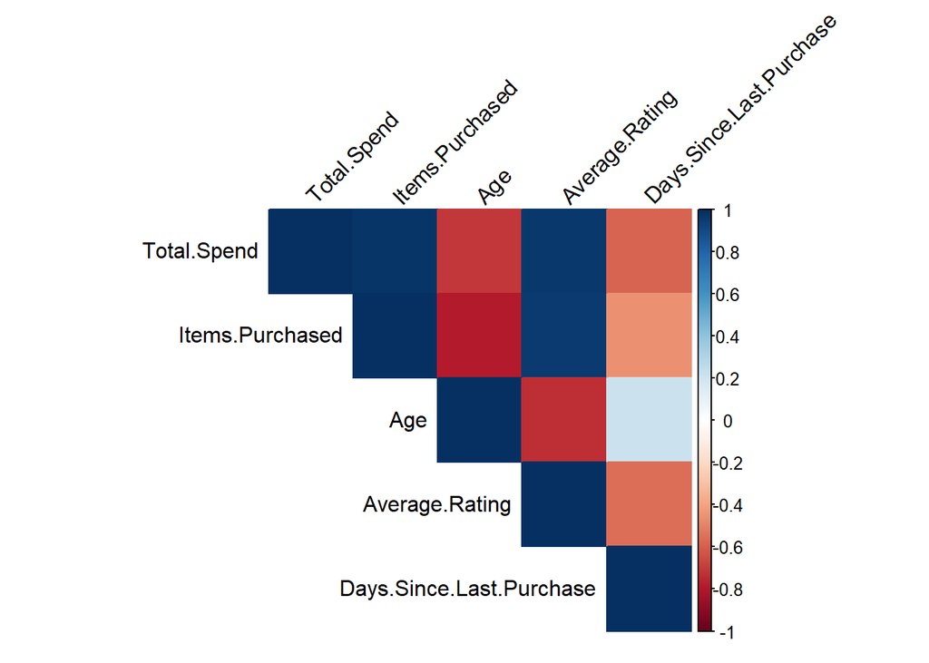

```r
cor = cor(ecommerce[, c("Total.Spend", "Items.Purchased", "Age", "Average.Rating", "Days.Since.Last.Purchase")],
          method = "spearman")
corrplot(cor, method = "color", type = "upper", tl.col = "black", tl.srt = 45)
```

Mam silnie zależną liczbę posiadanych produktów od wydatków, co jest dość logiczne, że skoro kupił dużo produktów to suma jego wydatków z każdym kolejnym produktem się zwiększa. Od tych dwóch zmiennych silnie zależy także średnia ocena zakupionych produktów.

# Pytania badawcze

## 1. Sprawdźmy do jakiej grupy klientów trafia firma?

O jakiej strukturze wieku i płci, z jakiego miasta.

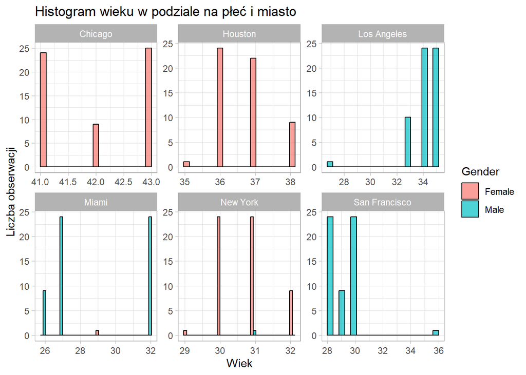

```r
ggplot(ecommerce, aes(x = Age, fill = Gender)) +
  geom_histogram(position = "dodge", bins = 20, color = "black", alpha = 0.7) +
  facet_wrap(~City, scales = "free") +
  labs(title = "Histogram wieku w podziale na płeć i miasto", x = "Wiek", y = "Liczba obserwacji") +
  theme_light()
```

Istnieje tutaj zróżnicowanie demograficzne miast, co można zauważyć po różnicach w strukturze wiekowej i płciowej. Widzimy tutaj, że z miast Chicago, Houston i New York kupują głównie kobiety w wieku 29-43 lat. Mężczyźni zaś są głównie z miast Los Angeles, Miami, San Francisco i ich przedział wiekowy to od 26-36 lat. Na podstawie tych danych, firma może rozważyć skoncentrowanie działań marketingowych skierowanych do danej grupy wiekowej i płciowej w zależności od specyfiki poszczególnych miast. Można także dostosować specyfikę produktów, ofert promocyjnych itp., aby lepiej odpowiadały charakterystyce danej grupy docelowej w konkretnym obszarze.

## 2.Sprawdźmy więc, z jakich miast klienci najwięcej wydają.

```r
ecommerce %>%
  group_by(City) %>%
  summarise(liczba = n(),
            średnia = mean(Total.Spend),
            mediana = median(Total.Spend),
            odchyl_stand = sd(Total.Spend)) %>%
  arrange(średnia)
```

| City | liczba | średnia | mediana | odchyl_stand |
| --- | --- | --- | --- | --- |
| Houston | 56 | 447.6482 | 440.90 | 17.56029 |
| Chicago | 58 | 499.8828 | 500.75 | 15.27790 |
| Miami | 58 | 690.3897 | 690.60 | 19.32483 |
| Los Angeles | 59 | 805.4915 | 800.90 | 17.18948 |
| New York | 59 | 1165.0356 | 1160.60 | 24.61186 |
| San Francisco | 58 | 1459.7724 | 1470.50 | 42.24118 |

W każdej grupie rozkład jest skoncentrowany wokół średniej - odchylenia są niewielkie. Możemy stwierdzić, że zdecydowanie najwięcej wydają klienci z miast San Francisco i New York, a najmniej z Houston i Chicago. Różnice te mogą wynikać z różnic w poziomie życia, czy dochodach. Zważywszy na to, że klienci z San Francisco i New York wydają znacznie więcej, firmy mogą skoncentrować się na tych obszarach oraz ich demografii w celu przyciągnięcia większej liczby klientów.

Zobrazujmy to jeszcze za pomocą boxplotów:

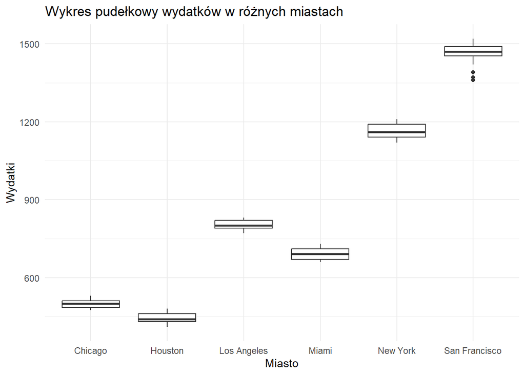

```r
ecommerce %>%
  ggplot() +
  geom_boxplot(aes(x = City, y = Total.Spend)) +
  labs(title = "Wykres pudełkowy wydatków w różnych miastach", x = "Miasto", y = "Wydatki") +
  theme_minimal()
```

Widzimy, że nasze wcześniejsze wnioski się potwierdzają.